# Impact of metformin on diabetes-related readmission

PH241: Team Data Project

Andrew Nguyen, Jessica Pak, Joanne Yang

Spring 2022

### Research Rationale

- Diabetes mellitus has been a worsening crisis: from 20 million patients in 2010 to 50 million by 2050 (Gregg et al. 2014).
- Hospital readmission is an indicator of worse patient outcomes
- Imperative to advocate for better preventive efforts and to understand which treatment and adaptation options are most effective.
- Insulin long-term efficacy and safety is not established. Metformin have shown promising results.
- Race in the United States’ society and healthcare system plays an outsized role in determining access and quality of care.

### The Research Questions

**Does diabetes medication impact the probability of hospital readmission amongst patients with diabetes?**

- Insulin vs. metformin?

**Does diabetes medication impact the probability of earlier hospital readmission (<30 days vs. >30 days)?**

- Does race influence either of these relationships?

# Methods

- **Study design**: cohort study with nested case-control analysis
- Each observation is a unique patient, their visit details, and their readmission outcome
- **Estimand**: odds of readmission given medication type and other covariates

**Dataset from CERNER health centers**

- Nationally representative hospital sample
- Large sample size, mostly complete data
- May be prone to selection bias (issues with healthcare access, fragmented systems)

**Data Cleaning Objectives:**

- Create binary indicator variables for drug classes (any prescription of said drug = 1, else = 0)
- Create indicator variables for categorical variables (race, sex, type of admission source, etc.)
- Create age range indicator variables
- Create diagnosis indicator variables for groups of ICD-10 codes
- Factor all categorical variables

# Methods

**Missingness**

- Investigate missingness as a function of observed covariates
- Subset missing values that cannot be imputed (categorical variables)

We decide to build propensity scores as a function of these covariates reflecting patient-provider social dynamics and severity of disease.

**Positivity**

- Investigate propensity of treatment as a function of covariates thought to be associated with receiving treatment; subset unexchangeable observations
- Matched observations on propensity score without replacement
- Perform sensitivity analysis using propensity score weights on non-matched data

# Methods

**Two models of interest:**

We created two datasets with two distinct partitions of the response variable:

- **Model 1**: Relationship between medication type and readmission at all (no readmission vs. all readmission)
- **Model 2**: Relationship between medication type and time earlier readmission (<30 days vs. >30 days)

**Assumptions:**

*Propensity scores*:

- Covariates that would affect propensity of treatment
- Unobserved covariates likely exist

*Models*:

- Outcome variable is binary
- Linearity between log odds of the outcome and each continuous predictor variable
- Observations (individual patients) are independent of each other
- Little to no multicollinearity among independent variables
- No extreme outliers

### Causal Framework: Directed Acyclic Graph of treatment/outcome relationship

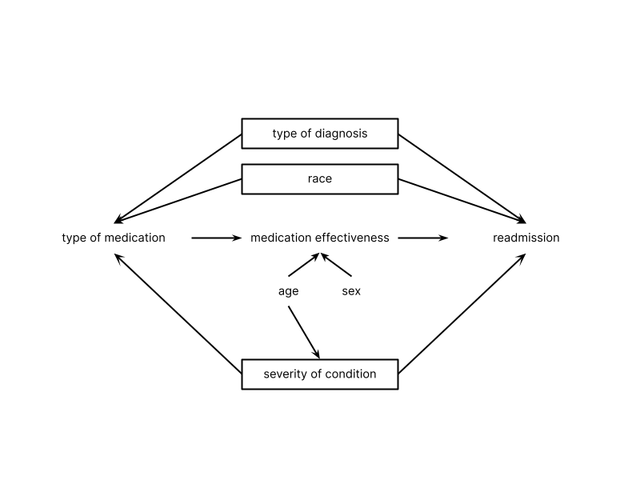

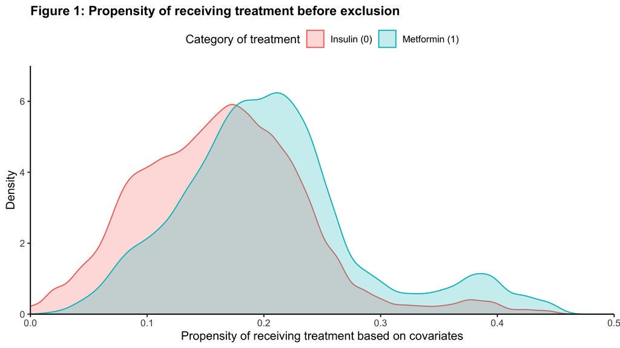

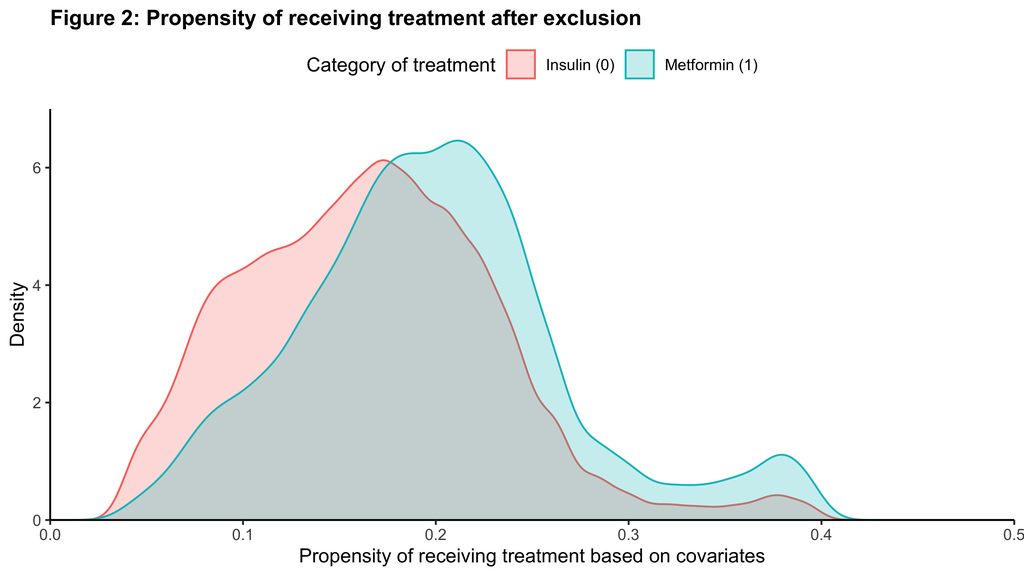

Descriptive analysis revealed that unexchangeable observations were more white, had fewer markers of disease severity, and were readmitted at lower rates.

# Results

**Table 1: Predictors of interest, descriptives**

[interactive table not shown]

Note: percentages may not sum to 100% due to unreported categories not included for legibility.

# Results

**Readmission vs. No Readmission Summaries**

| Model | Predictor | Estimate | Standard Error | Statistic | P-value |
| --- | --- | --- | --- | --- | --- |
| Matched | Medication: Metformin | 0.699405033551529 | 0.0408170664264431 | -8.75921002471702 | 1.96623464871414e-18 |
| Matched | Race: Black | 1.87672985370648 | 1.03856354216513 | 0.606155326259673 | 0.544411614855027 |
| Matched | Race: Hispanic | 0.689547606960808 | 0.773701474267157 | -0.480443104824082 | 0.630912350190226 |
| Matched | Race: Other | 0.709665854884826 | 0.8680664058698 | -0.395086187335541 | 0.692779282318214 |
| Weighted | Medication: Metformin | 0.928665057918467 | 0.0183800426232621 | -4.02649477747774 | 5.66144962984805e-05 |
| Weighted | Race: Black | 0.827159337025524 | 0.0304277897203221 | -6.23633643941929 | 4.47937190179395e-10 |
| Weighted | Race: Hispanic | 0.72206241006881 | 0.0843469465450973 | -3.86076457566191 | 0.000113032772704982 |
| Weighted | Race: Other | 0.694042916765583 | 0.0919285892580275 | -3.97288246904732 | 7.10080907326835e-05 |

Note: P-values under 0.05 are highlighted green.

# Results

**Readmission vs. No Readmission Coefficients**

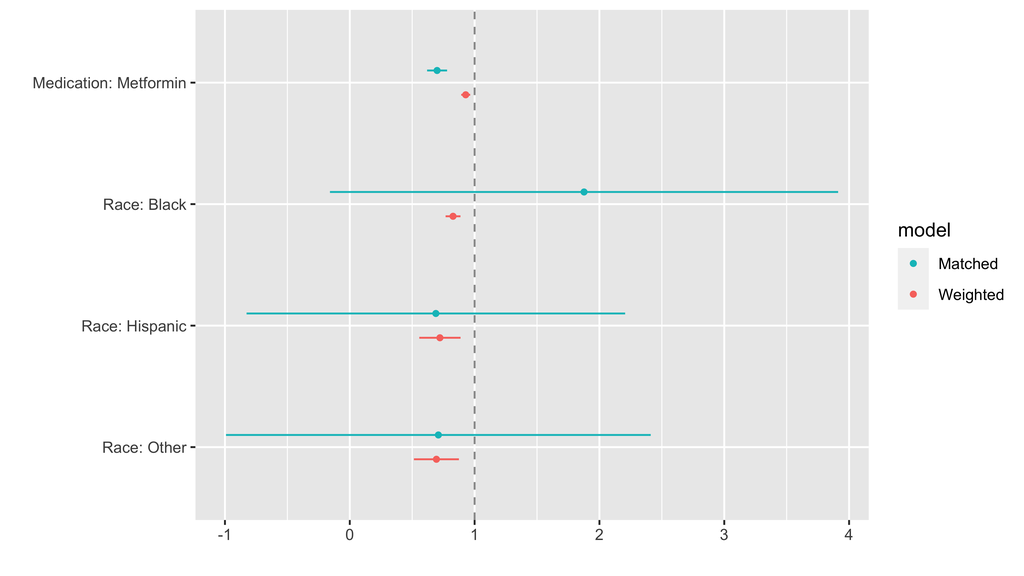

**Readmission <=30 vs. >30 days Summaries**

| Model | Predictor | Estimate | Standard Error | Statistic | P-value |
| --- | --- | --- | --- | --- | --- |
| Matched | Medication: Metformin | 0.871655812818731 | 1.08033455667211 | -1.77765339807173 | 0.0754607979417964 |
| Matched | Race: Black | 0.0970889540294413 | 4.21973599317229 | -1.61978893415669 | 0.105277624168085 |
| Matched | Race: Hispanic | 0.110384495762003 | 5.30025199911128 | -1.32140897742471 | 0.186365034281314 |
| Matched | Race: Other | 1.19645469804734 | 5.09609756352754 | 0.110141548767833 | 0.912297117434898 |
| Weighted | Medication: Metformin | 0.934254459042681 | 1.03385336386234 | -2.04266772803255 | 0.0410853415645368 |
| Weighted | Race: Black | 1.01336490362894 | 1.05850340167078 | 0.233508781194339 | 0.815366351603168 |
| Weighted | Race: Hispanic | 0.87141069078182 | 1.18706174167206 | -0.80266497855192 | 0.422168400210066 |
| Weighted | Race: Other | 0.819855344349188 | 1.20732702857933 | -1.05423585439103 | 0.291774948476757 |

Note: P-values under 0.05 are highlighted green.

# Results

**Readmission <=30 vs. >30 days Coefficients**

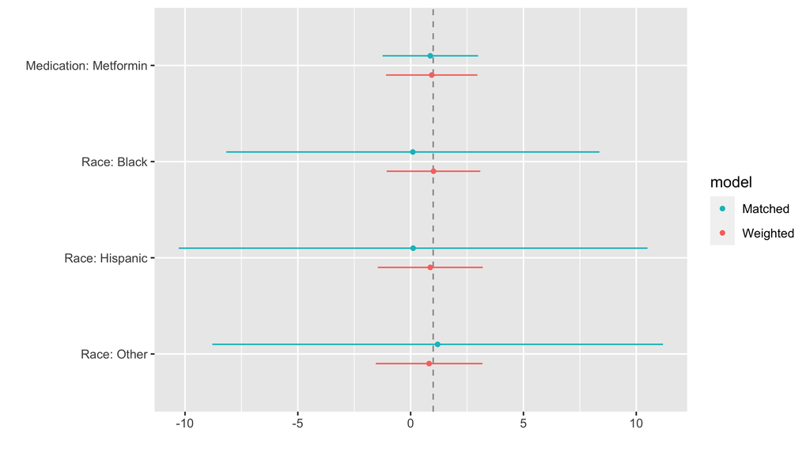

# Discussion

# Discussion

**Limitations**

- Causal mechanism of model may be incorrect
- Lost nuance of data when binarizing variables
- Treatment groups only balanced in observed covariates
- Analytical dataset was much smaller than the original

**Conclusions & Recommendations**

- These evidence support prior and continuing clinical research that outline metformin as standard of care for T2DM.
- We support the current recommendation of T2DM care moving towards metformin, and for further studies where multiple outcomes and >2 drug classes can be explored to more reflect reality.